# Predicting Fire Behavior Using Weather & Meteorological Data

### 3.Transforming the response variable

The histogram below illustrates the distribution of the response variable as right-skewed. To prevent a normality violation in the regressional model, the data is transformed by taking the natural log of all ISI data.

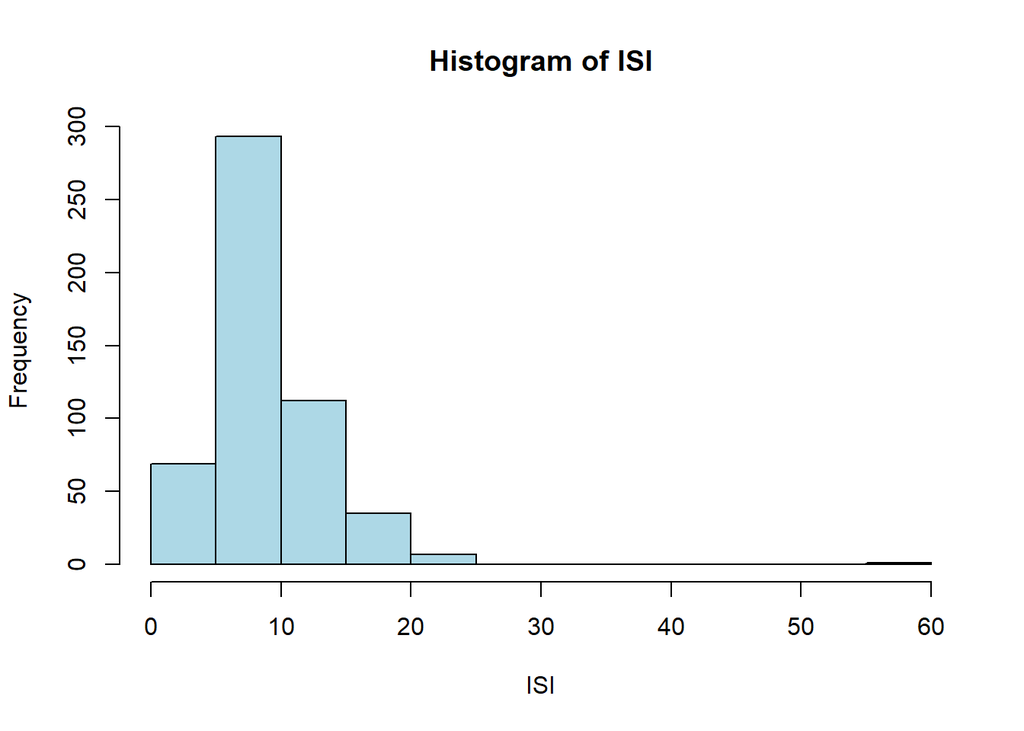

```r
#check normality of response variable
hist(fire$ISI, col = "lightblue", xlab = "ISI", main = "Histogram of ISI")
```

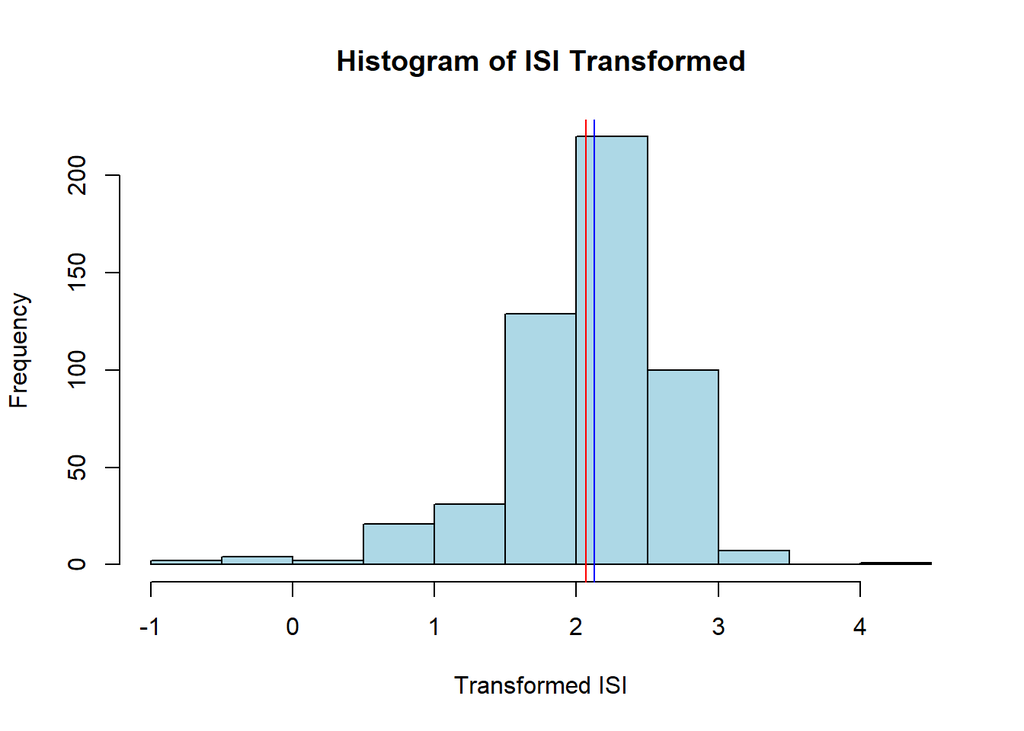

```r
#transform data by taking log
trans = log(fire$ISI)

#change  the below case or error occurs
trans[380] = 1.2

hist(trans, xlab = "Transformed ISI", col = "lightblue", main = "Histogram of ISI Transformed")
abline(v = mean(trans), col = 'red')
abline(v = median(trans), col = 'blue')
```

Consequentially, the distribution the response variable (ISI) is now normal, and we can proceed with selecting the appropriate features for our model. A QQ-normal plot is shown below to illustrate that the residual data is normally distributed.

```r
#png("qqnorm.png", units = "px", width=960, height=960)
#use QQ plot check model
summary(lm(trans ~.-ISI - season_ + factor(season_) , data = fire))
```

```
##
## Call:
## lm(formula = trans ~ . - ISI - season_ + factor(season_), data = fire)
##
## Residuals:
##      Min       1Q   Median       3Q      Max
## -0.88416 -0.18826 -0.01478  0.15555  1.41482
##
## Coefficients:
##                         Estimate Std. Error t value Pr(>|t|)
## (Intercept)           -7.5020503  0.3253664 -23.057  < 2e-16 ***
## FFMC                   0.1032423  0.0031915  32.349  < 2e-16 ***
## DMC                   -0.0002699  0.0003285  -0.821 0.411758
## DC                    -0.0001727  0.0001446  -1.194 0.232890
## temp                   0.0033244  0.0039828   0.835 0.404288
## RH                     0.0023911  0.0010969   2.180 0.029735 *
## wind                   0.0399209  0.0070624   5.653 2.65e-08 ***
## rain                  -0.0281188  0.0414902  -0.678 0.498258
## area                  -0.0000836  0.0001897  -0.441 0.659678
## factor(season_)spring -0.1859825  0.0955907  -1.946 0.052256 .
## factor(season_)summer  0.0844774  0.0385585   2.191 0.028916 *
## factor(season_)winter -0.3526551  0.0977276  -3.609 0.000339 ***
## ---
## Signif. codes:  0 '***' 0.001 '**' 0.01 '*' 0.05 '.' 0.1 ' ' 1
##
## Residual standard error: 0.2712 on 505 degrees of freedom
## Multiple R-squared:  0.7781, Adjusted R-squared:  0.7732
## F-statistic: 160.9 on 11 and 505 DF,  p-value: < 2.2e-16
```

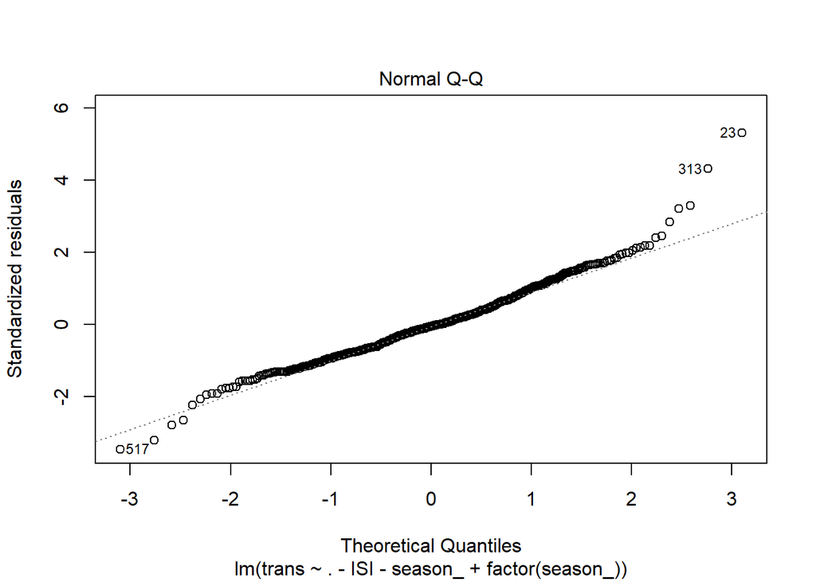

```r
plot(lm(trans ~.-ISI - season_ + factor(season_), data = fire),2)
```

```r
#dev.off()
```

### 4.Examining Multicolinearity

Multicolinearity occurs when predictor variables are linearly correlated with the other. This implies that a change in any one of the predictor variables would entail a change in another highly correlated predictor variable.

Before we proceed to fit our model it is important to perform two vital checks. Firstly, there needs to be a reasonable correlation between the predictor variables and the response variable. An absence of any linear pattern does not warrant the use of a linear regression problem.

#### Colinearity Between Predictor Variables

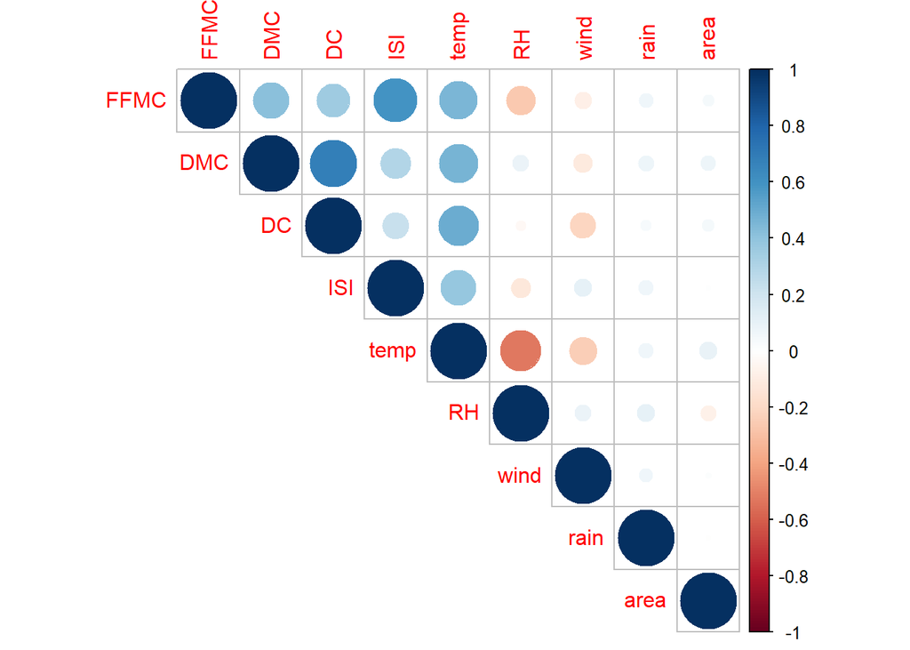

```r
#removing seasons for correlation
fire_cor <- fire[,-match(c('season_'),names(fire))]

#Checking for multicolinearity. Here we will compare each of our predictor variables with all the others predictor variables.
corr<-cor(fire_cor)
#plotting correlation head map
#png("corrplot.png", units = "px", width=960, height=960)
corrplot(corr, type = 'upper')
```

```r
#dev.off()
```

#### Correlation Between Predictor and Response Variable

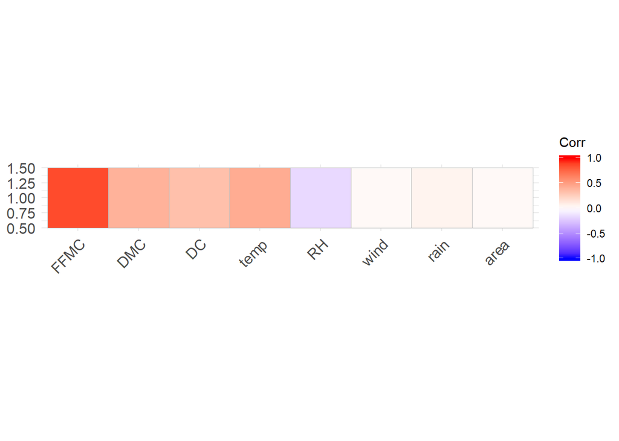

```r
#1. Visualizing correlations between our response variable and the predictor variable
# Comparing Y with all other predictor variables *(X's)
corr1<-cor(x = fire_cor[,-4], y = trans, use="complete.obs")

#png("qqnorm.png", units = "px")
ggcorrplot(corr1)
```

```r
#dev.off()
```

However to further confirm our claim, we will employ the use of the Variance Inflation Factor analysis. This analysis allows us to support / reject our claim using numerical proof. It is important to note that the lower the VIF (lowest being 1), the less multicolinearity exists in our dataset. A VIF of 5 represents industry standard acceptance rate for multicolinearity as a small value indicates that the standard deviation of the respective variable parameter will remain relatively stable when other predictor variables are added into the regression equation.

```r
#Calculate the Variance Inflation Factor for each of the predictor variables
model <- lm(trans~ fire$FFMC + fire$DMC + fire$DC + fire$temp + fire$RH + fire$wind + fire$rain + fire$area + factor(fire$season_) , data = fire)
#summary(model)
vif(model)
```

```
##                           GVIF Df GVIF^(1/(2*Df))
## fire$FFMC             1.459696  1        1.208179
## fire$DMC              3.101415  1        1.761083
## fire$DC               9.060482  1        3.010063
## fire$temp             3.730699  1        1.931502
## fire$RH               2.198147  1        1.482615
## fire$wind             1.122068  1        1.059277
## fire$rain             1.058029  1        1.028605
## fire$area             1.023608  1        1.011735
## factor(fire$season_) 14.581963  3        1.563037
```

# 2.5 Results & Discussion

After analyzing the correlation of the predictor variables in the dataset, the next steps comprise the following:  
1. Feature Selection  
2. Model fitting using Training Data  
3. Analysis

### 1.Feature Selection

Using stepwise regression, we iterate through different possibilities of a linear model and choose one with features yileding the best (lowest) error metric.

The QQ-normal plot below illustrates the distribution of our data after utilizing stepwise regression for feature selection.

```r
# forward stepwise regression
model = lm(trans ~.-ISI - season_ + factor(season_), data = fire)
new_model = step(model)
```

```
## Start:  AIC=-1337.49
## trans ~ (season_ + FFMC + DMC + DC + ISI + temp + RH + wind +
##     rain + area) - ISI - season_ + factor(season_)
##
##                   Df Sum of Sq     RSS      AIC
## - area             1     0.014  37.150 -1339.30
## - rain             1     0.034  37.170 -1339.02
## - DMC              1     0.050  37.186 -1338.80
## - temp             1     0.051  37.187 -1338.78
## - DC               1     0.105  37.241 -1338.04
## <none>                          37.136 -1337.49
## - RH               1     0.349  37.486 -1334.65
## - factor(season_)  3     2.223  39.359 -1313.44
## - wind             1     2.350  39.486 -1307.78
## - FFMC             1    76.954 114.091  -759.21
##
## Step:  AIC=-1339.3
## trans ~ FFMC + DMC + DC + temp + RH + wind + rain + factor(season_)
##
##                   Df Sum of Sq     RSS      AIC
## - rain             1     0.033  37.184 -1340.83
## - temp             1     0.048  37.199 -1340.62
## - DMC              1     0.055  37.205 -1340.53
## - DC               1     0.101  37.251 -1339.90
## <none>                          37.150 -1339.30
## - RH               1     0.353  37.504 -1336.41
## - factor(season_)  3     2.249  39.400 -1314.90
## - wind             1     2.338  39.488 -1309.74
## - FFMC             1    76.978 114.129  -761.04
##
## Step:  AIC=-1340.83
## trans ~ FFMC + DMC + DC + temp + RH + wind + factor(season_)
##
##                   Df Sum of Sq     RSS      AIC
## - temp             1     0.037  37.221 -1342.32
## - DMC              1     0.052  37.235 -1342.12
## - DC               1     0.108  37.292 -1341.33
## <none>                          37.184 -1340.83
## - RH               1     0.324  37.508 -1338.34
## - factor(season_)  3     2.315  39.498 -1315.61
```

[output cut: 10 more lines]

```
## - RH               1     0.355  37.576 -1339.41
## - wind             1     2.273  39.494 -1313.68
## - factor(season_)  3     3.918  41.139 -1296.57
## - FFMC             1    77.501 114.722  -762.36
##
## Step:  AIC=-1343.79
## trans ~ FFMC + DC + RH + wind + factor(season_)
##
##                   Df Sum of Sq     RSS      AIC
## <none>                          37.258 -1343.79
## - DC               1     0.319  37.577 -1341.39
## - RH               1     0.323  37.582 -1341.33
## - wind             1     2.298  39.556 -1314.86
## - factor(season_)  3     3.999  41.258 -1297.08
## - FFMC             1    80.155 117.414  -752.37
```

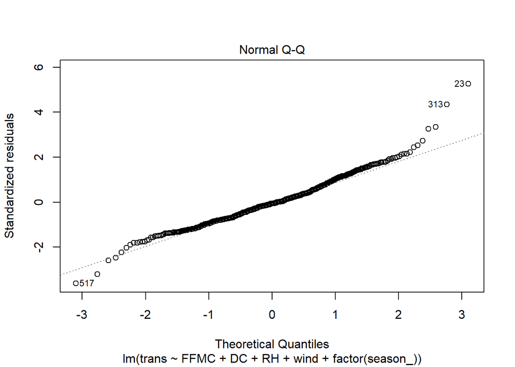

```r
#new model QQ plot
#png("qqnorm2.png", units = "px", width=960, height=960)
plot(new_model, 2)
```

```r
#dev.off()

new_model$terms
```

```
## trans ~ FFMC + DC + RH + wind + factor(season_)
## attr(,"variables")
## list(trans, FFMC, DC, RH, wind, factor(season_))
## attr(,"factors")
##                 FFMC DC RH wind factor(season_)
## trans              0  0  0    0               0
## FFMC               1  0  0    0               0
## DC                 0  1  0    0               0
## RH                 0  0  1    0               0
## wind               0  0  0    1               0
## factor(season_)    0  0  0    0               1
## attr(,"term.labels")
## [1] "FFMC"            "DC"              "RH"              "wind"
## [5] "factor(season_)"
## attr(,"order")
## [1] 1 1 1 1 1
## attr(,"intercept")
## [1] 1
## attr(,"response")
## [1] 1
## attr(,".Environment")
## <environment: R_GlobalEnv>
## attr(,"predvars")
## list(trans, FFMC, DC, RH, wind, factor(season_))
## attr(,"dataClasses")
##           trans            FFMC              DC              RH
##       "numeric"       "numeric"       "numeric"       "numeric"
##            wind factor(season_)
##       "numeric"        "factor"
```

### 2. Fitting the model

A portion of the data is separated to be utilized as a training set, while the remaining portion will be utilized as a test set.This will allow the accuracy of the model to be measured.

```r
#attaching the trans column to the main fire dataset
fire_to_split <- cbind(fire, trans)

#Get 400 random numbers
ran <- sample(1:517, 400, replace=F)

#splitting the dataset into training and testing
train <- fire_to_split[ran,]

#test data: contains data not in training data
test = setdiff(fire_to_split, train)
```

```r
#fitting the model
m = lm(train$trans ~ FFMC + temp + RH + wind - ISI - trans - season_ + factor(season_), data = train)
summary(m)
```

```
##
## Call:
## lm(formula = train$trans ~ FFMC + temp + RH + wind - ISI - trans -
##     season_ + factor(season_), data = train)
##
## Residuals:
##      Min       1Q   Median       3Q      Max
## -0.81838 -0.18778 -0.01728  0.16500  0.89397
##
## Coefficients:
##                        Estimate Std. Error t value Pr(>|t|)
## (Intercept)           -7.168820   0.318817 -22.486  < 2e-16 ***
## FFMC                   0.098745   0.003237  30.503  < 2e-16 ***
## temp                   0.001544   0.004250   0.363 0.716608
## RH                     0.001828   0.001154   1.585 0.113792
## wind                   0.034982   0.007825   4.470 1.02e-05 ***
## factor(season_)spring -0.058764   0.053398  -1.100 0.271795
## factor(season_)summer  0.093180   0.032562   2.862 0.004441 **
## factor(season_)winter -0.244167   0.070677  -3.455 0.000611 ***
## ---
## Signif. codes:  0 '***' 0.001 '**' 0.01 '*' 0.05 '.' 0.1 ' ' 1
##
## Residual standard error: 0.2677 on 392 degrees of freedom
## Multiple R-squared:  0.7863, Adjusted R-squared:  0.7825
## F-statistic:   206 on 7 and 392 DF,  p-value: < 2.2e-16
```

### 4. Cooks distance

After fitting the model, cook’s distance is utilized to analyze if any influential data points affect the regression line. If any exist, this decreases the model’s ability to generalize.

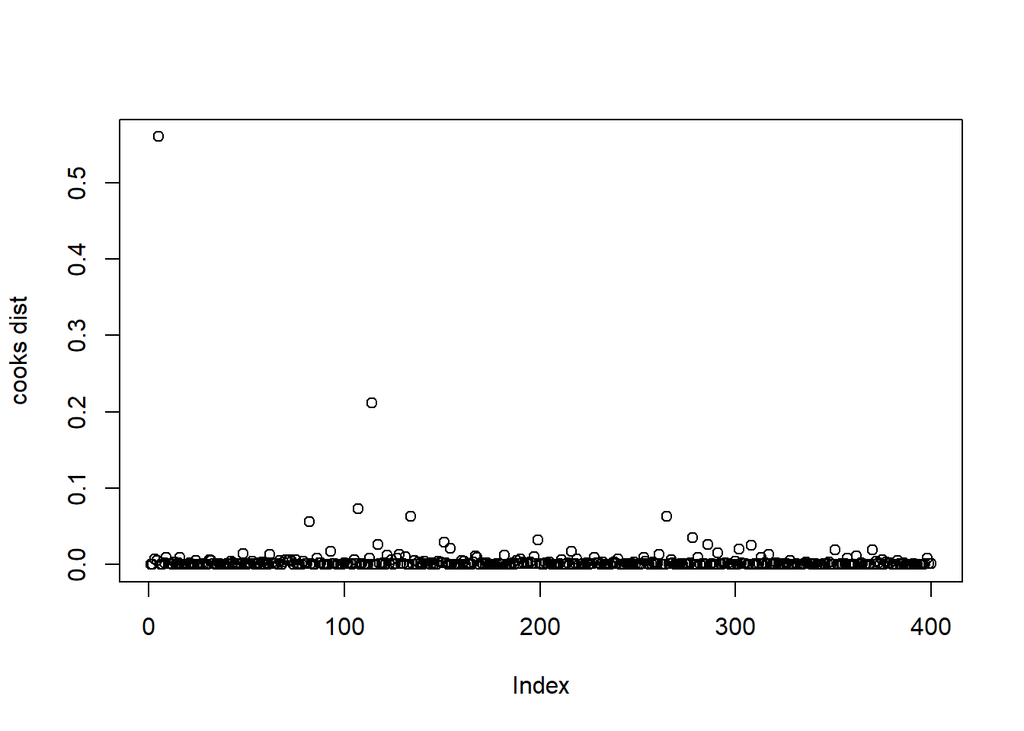

```r
#cooks distance
library(stats)
cook = cooks.distance(m)   # here m is the linear mode

#png("cook.png", units = "px", width=960, height=960)
plot(cook, ylab = 'cooks dist')
```

```r
#dev.off()
```

### 5. Testing the model

```r
sum_square_errors <- sum((test$trans - predict(m,newdata = test))^2)
sum_square_errors
```

```
## [1] 9.516024
```

```r
## Code archives

week = function(x){
  if(x == 'mon'){
    return(1)
  } else if(x == 'tue'){
    return(2)
  } else if(x == 'wed'){
    return(3)
  } else if(x == 'thu'){
    return(4)
  } else if(x == 'fri'){
    return(5)
  } else if(x == 'sat'){
    return(6)
  } else{
    return(7)
  }
}


#check correlation and distributions
#pairs.panels(fire)


#summary(lm(trans ~ month + FFMC + temp + RH + wind, data = fire))
#displaying first 5 rows
```

Footnotes:

[^1]: http://cwfis.cfs.nrcan.gc.ca/background/summary/fwi
[^2]: http://cwfis.cfs.nrcan.gc.ca/background/summary/fwi